MRC Centre for Global Infectious Disease Analysis, Imperial College London

# Imperial College COVID-19 LMIC Reports

## Future scenarios of the healthcare burden of COVID-19 in Low- or Middle-Income Countries

COVID-19 has caused large-scale outbreaks in many countries, particularly in Europe and Asia where many countries have experienced a level of healthcare demand that have placed health systems under strain. Many countries, particularly Low- or Middle Income countries (LMICs) (shown below), are at an earlier stage of the epidemic. 41 countries have reported fewer than 100 COVID-19 deaths. However, following the implementation of widespread suppression measures around the world, COVID-19 burden is increasingly becoming concentrated in LMICs.

Here we aim to provide each country with an indication of where they are in their epidemic and scenarios of how healthcare demand is likely to vary over the next 28 days. Changes in transmission from today will also shape the next 28 days so these estimates should not be viewed as predictions but scenarios to help countries understand how strategies today are likely to shape the next phase of the epidemic. Specifically, these reports will aim to help countries understand:

#### 1. The total number of COVID-19 infections

#### 2. The expected number of deaths within the next 28 days

#### 3. The number of individuals requiring oxygen or mechanical ventilation in the next 28 days

#### 4. The impact of changing their current intervention policy

**For further guidance and questions about the methodology and caveats, please see the [Frequently Asked Questions](https://mrc-ide.github.io/global-lmic-reports-staging/FAQ.html)**

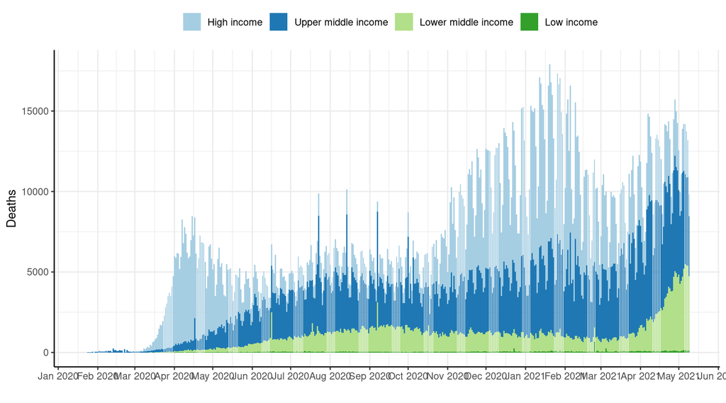

### Key aspects captured in our methodology (see methods and FAQs for full details)

- **Populations are typically younger in LMICs so, provided good access to care, the risk an average infection leads to mortality is lower.** We take the risk of severe disease and death by age as observed in China and Europe and country-specific demography to calibrate our model. For example, in low-income countries our estimated infection-fatality ratio (IFR) is typically around 2-3 deaths per 1000 infections, contrasted to the 6-10 deaths per 1000 infections observed in high-income countries with older populations.
- **Not all COVID-19 infections are reported.** Global testing capacity has improved substantially but both the percentage of cases that are detected and the proportion of infections that are symptomatic is likely to be highly variable by country and over time. Here our model is calibrated to reported deaths on the basis of our country-specific IFR.
- **The availability of healthcare varies by country.** We estimate the availability of hospital beds and intensive care units within each country using a range of publicly available datasets. These are typically lower in lower-income countries. As epidemics begin to exceed these thresholds in some countries our estimate of the risk of mortality upon infection will increase, as will our uncertainty in the future levels of mortality within these scenarios.
- **Control measures previously and currently being implemented.** Using data on the implementation of interventions and patterns of mobility our estimates capture the extent to which, on average, LMICs reacted at much earlier stages in their epidemics than their HIC counterparts.
- **Transmission is different in different countries.** We update our fitting each day incorporating all the data above. As a result, we are learning more about how transmission is changing in each country every day.

### Key remaining factors to consider

- **Local factors will also be key.** We attempt to provide a framework in which to understand how trends observed within a country relate to the global context of the COVID-19 pandemic however local knowledge can provide much more refined understanding (e.g. the age and vulnerability profile of observed deaths) than available here.
- **COVID-19 epidemics are likely to vary at much smaller spatial scale than the country-level.** There are likely to be sub-national differences in all data sources we are not able to capture (our open-source ‘squire’ package can be used to provide custom calibrations for countries with sub-national inputs)
- **Deaths can also be under-reported.** These reports are updated daily using the latest publicly available data on COVID-19 deaths from the European Centre for Disease Prevention and Control. If deaths are being under-estimated this will have an onwards impact on our estimates of healthcare demand.
- **Our scenarios only involve estimates of the direct impact of the virus.** Our estimates do not include either the indirect effect of the virus upon a health system (e.g. excess deaths due to reduced availability of other health services). Nor do we incorporate the wider social and economic implications of the virus or control measures.

### DATA

- The combined reports can be downloaded from [here](https://github.com/mrc-ide/global-lmic-reports-staging/blob/master/combined_reports.pdf)
- Projected infections, deaths and healthcare demands can be downloaded from [here](https://github.com/mrc-ide/global-lmic-reports-staging/raw/master/data/2021-05-08_v7.csv.zip)

### FUNDING

This project was funded jointly by the UK Foreign Commonwealth and Development Office and The Wellcome Trust

[figure not shown]

[figure not shown]

Copyright © 2020 Imperial College London. MRC Centre for Global Infectious Disease Analysis. All rights reserved.

Funded by the Wellcome Trust and The Department for International Development